# Project: Investigate a Dataset (Replace this with something more specific!)

```python
sum(df_team_attr.duplicated());
```

```
0
```

```python
# Load your data and print out a few lines. Perform operations to inspect data
#   types and look for instances of missing or possibly errant data.
df_player = pd.read_csv('player.csv', sep = ';');
df_player.head();
```

|  | id | player_api_id | player_name | player_fifa_api_id | birthday | height | weight |
| --- | --- | --- | --- | --- | --- | --- | --- |
| 0 | 1 | 505942 | Aaron Appindangoye | 218353 | 1992-02-29 00:00:00 | 182.88 | 187 |
| 1 | 2 | 155782 | Aaron Cresswell | 189615 | 1989-12-15 00:00:00 | 170.18 | 146 |
| 2 | 3 | 162549 | Aaron Doran | 186170 | 1991-05-13 00:00:00 | 170.18 | 163 |
| 3 | 4 | 30572 | Aaron Galindo | 140161 | 1982-05-08 00:00:00 | 182.88 | 198 |
| 4 | 5 | 23780 | Aaron Hughes | 17725 | 1979-11-08 00:00:00 | 182.88 | 154 |

```python
df_player.shape
```

```
(11060, 7)
```

```python
df_player.info();
```

```
<class 'pandas.core.frame.DataFrame'>
RangeIndex: 11060 entries, 0 to 11059
Data columns (total 7 columns):
 #   Column              Non-Null Count  Dtype
---  ------              --------------  -----
 0   id                  11060 non-null  int64
 1   player_api_id       11060 non-null  int64
 2   player_name         11060 non-null  object
 3   player_fifa_api_id  11060 non-null  int64
 4   birthday            11060 non-null  object
 5   height              11060 non-null  float64
 6   weight              11060 non-null  int64
dtypes: float64(1), int64(4), object(2)
memory usage: 605.0+ KB
```

```python
sum(df_player.duplicated());
```

```
0
```

```python
# Load your data and print out a few lines. Perform operations to inspect data
#   types and look for instances of missing or possibly errant data.
df_player_attr = pd.read_csv('player_attributes.csv', sep = ';');
df_player_attr.head();
```

|  | id | player_fifa_api_id | player_api_id | date | overall_rating | potential | preferred_foot | attacking_work_rate | defensive_work_rate | crossing | ... | vision | penalties | marking | standing_tackle | sliding_tackle | gk_diving | gk_handling | gk_kicking | gk_positioning | gk_reflexes |
| --- | --- | --- | --- | --- | --- | --- | --- | --- | --- | --- | --- | --- | --- | --- | --- | --- | --- | --- | --- | --- | --- |
| 0 | 1 | 218353 | 505942 | 2016-02-18 00:00:00 | 67.0 | 71.0 | right | medium | medium | 49.0 | ... | 54.0 | 48.0 | 65.0 | 69.0 | 69.0 | 6.0 | 11.0 | 10.0 | 8.0 | 8.0 |
| 1 | 2 | 218353 | 505942 | 2015-11-19 00:00:00 | 67.0 | 71.0 | right | medium | medium | 49.0 | ... | 54.0 | 48.0 | 65.0 | 69.0 | 69.0 | 6.0 | 11.0 | 10.0 | 8.0 | 8.0 |
| 2 | 3 | 218353 | 505942 | 2015-09-21 00:00:00 | 62.0 | 66.0 | right | medium | medium | 49.0 | ... | 54.0 | 48.0 | 65.0 | 66.0 | 69.0 | 6.0 | 11.0 | 10.0 | 8.0 | 8.0 |
| 3 | 4 | 218353 | 505942 | 2015-03-20 00:00:00 | 61.0 | 65.0 | right | medium | medium | 48.0 | ... | 53.0 | 47.0 | 62.0 | 63.0 | 66.0 | 5.0 | 10.0 | 9.0 | 7.0 | 7.0 |
| 4 | 5 | 218353 | 505942 | 2007-02-22 00:00:00 | 61.0 | 65.0 | right | medium | medium | 48.0 | ... | 53.0 | 47.0 | 62.0 | 63.0 | 66.0 | 5.0 | 10.0 | 9.0 | 7.0 | 7.0 |

5 rows × 42 columns

```python
df_player_attr.shape
```

```
(183978, 42)
```

```python
df_player_attr.info();
```

```
<class 'pandas.core.frame.DataFrame'>
RangeIndex: 183978 entries, 0 to 183977
Data columns (total 42 columns):
 #   Column               Non-Null Count   Dtype
---  ------               --------------   -----
 0   id                   183978 non-null  int64
 1   player_fifa_api_id   183978 non-null  int64
 2   player_api_id        183978 non-null  int64
 3   date                 183978 non-null  object
 4   overall_rating       183142 non-null  float64
 5   potential            183142 non-null  float64
 6   preferred_foot       183142 non-null  object
 7   attacking_work_rate  180748 non-null  object
 8   defensive_work_rate  183142 non-null  object
 9   crossing             183142 non-null  float64
```

[output cut: 34 more lines]

```python
sum(df_player_attr.duplicated());
```

```
0
```

```python
df_player_attr.describe();
```

|  | id | player_fifa_api_id | player_api_id | overall_rating | potential | crossing | finishing | heading_accuracy | short_passing | volleys | ... | vision | penalties | marking | standing_tackle | sliding_tackle | gk_diving | gk_handling | gk_kicking | gk_positioning | gk_reflexes |
| --- | --- | --- | --- | --- | --- | --- | --- | --- | --- | --- | --- | --- | --- | --- | --- | --- | --- | --- | --- | --- | --- |
| count | 183978.00000 | 183978.000000 | 183978.000000 | 183142.000000 | 183142.000000 | 183142.000000 | 183142.000000 | 183142.000000 | 183142.000000 | 181265.000000 | ... | 181265.000000 | 183142.000000 | 183142.000000 | 183142.000000 | 181265.000000 | 183142.000000 | 183142.000000 | 183142.000000 | 183142.000000 | 183142.000000 |
| mean | 91989.50000 | 165671.524291 | 135900.617324 | 68.600015 | 73.460353 | 55.086883 | 49.921078 | 57.266023 | 62.429672 | 49.468436 | ... | 57.873550 | 55.003986 | 46.772242 | 50.351257 | 48.001462 | 14.704393 | 16.063612 | 20.998362 | 16.132154 | 16.441439 |
| std | 53110.01825 | 53851.094769 | 136927.840510 | 7.041139 | 6.592271 | 17.242135 | 19.038705 | 16.488905 | 14.194068 | 18.256618 | ... | 15.144086 | 15.546519 | 21.227667 | 21.483706 | 21.598778 | 16.865467 | 15.867382 | 21.452980 | 16.099175 | 17.198155 |
| min | 1.00000 | 2.000000 | 2625.000000 | 33.000000 | 39.000000 | 1.000000 | 1.000000 | 1.000000 | 3.000000 | 1.000000 | ... | 1.000000 | 2.000000 | 1.000000 | 1.000000 | 2.000000 | 1.000000 | 1.000000 | 1.000000 | 1.000000 | 1.000000 |
| 25% | 45995.25000 | 155798.000000 | 34763.000000 | 64.000000 | 69.000000 | 45.000000 | 34.000000 | 49.000000 | 57.000000 | 35.000000 | ... | 49.000000 | 45.000000 | 25.000000 | 29.000000 | 25.000000 | 7.000000 | 8.000000 | 8.000000 | 8.000000 | 8.000000 |
| 50% | 91989.50000 | 183488.000000 | 77741.000000 | 69.000000 | 74.000000 | 59.000000 | 53.000000 | 60.000000 | 65.000000 | 52.000000 | ... | 60.000000 | 57.000000 | 50.000000 | 56.000000 | 53.000000 | 10.000000 | 11.000000 | 12.000000 | 11.000000 | 11.000000 |
| 75% | 137983.75000 | 199848.000000 | 191080.000000 | 73.000000 | 78.000000 | 68.000000 | 65.000000 | 68.000000 | 72.000000 | 64.000000 | ... | 69.000000 | 67.000000 | 66.000000 | 69.000000 | 67.000000 | 13.000000 | 15.000000 | 15.000000 | 15.000000 | 15.000000 |
| max | 183978.00000 | 234141.000000 | 750584.000000 | 94.000000 | 97.000000 | 95.000000 | 97.000000 | 98.000000 | 97.000000 | 93.000000 | ... | 97.000000 | 96.000000 | 96.000000 | 95.000000 | 95.000000 | 94.000000 | 93.000000 | 97.000000 | 96.000000 | 96.000000 |

8 rows × 38 columns

> **Tip**: You should *not* perform too many operations in each cell. Create cells freely to explore your data. One option that you can take with this project is to do a lot of explorations in an initial notebook. These don't have to be organized, but make sure you use enough comments to understand the purpose of each code cell. Then, after you're done with your analysis, create a duplicate notebook where you will trim the excess and organize your steps so that you have a flowing, cohesive report.

> **Tip**: Make sure that you keep your reader informed on the steps that you are taking in your investigation. Follow every code cell, or every set of related code cells, with a markdown cell to describe to the reader what was found in the preceding cell(s). Try to make it so that the reader can then understand what they will be seeing in the following cell(s).

```python
df_team_improved = pd.merge(df_team, df_team_attr, on = 'team_api_id');
df_team_improved.head(2);
```

|  | id_x | team_api_id | team_fifa_api_id_x | team_long_name | team_short_name | id_y | team_fifa_api_id_y | date | buildUpPlaySpeed | buildUpPlaySpeedClass | ... | chanceCreationShooting | chanceCreationShootingClass | chanceCreationPositioningClass | defencePressure | defencePressureClass | defenceAggression | defenceAggressionClass | defenceTeamWidth | defenceTeamWidthClass | defenceDefenderLineClass |
| --- | --- | --- | --- | --- | --- | --- | --- | --- | --- | --- | --- | --- | --- | --- | --- | --- | --- | --- | --- | --- | --- |
| 0 | 1 | 9987 | 673.0 | KRC Genk | GEN | 485 | 673 | 2010-02-22 00:00:00 | 45 | Balanced | ... | 60 | Normal | Organised | 70 | High | 65 | Press | 70 | Wide | Cover |
| 1 | 1 | 9987 | 673.0 | KRC Genk | GEN | 486 | 673 | 2011-02-22 00:00:00 | 66 | Balanced | ... | 51 | Normal | Organised | 48 | Medium | 47 | Press | 54 | Normal | Offside Trap |

2 rows × 29 columns

```python
df_team_improved.drop(['id_x', 'id_y', 'team_fifa_api_id_x', 'team_fifa_api_id_y', 'buildUpPlaySpeedClass', 'buildUpPlayDribblingClass', 'buildUpPlayPassingClass', 'buildUpPlayPositioningClass', 'chanceCreationPassingClass', 'chanceCreationCrossingClass', 'chanceCreationShootingClass', 'chanceCreationPositioningClass', 'defencePressureClass', 'defenceAggressionClass', 'defenceTeamWidthClass', 'defenceDefenderLineClass'], axis = 1, inplace = True);
```

```python
df_team_improved.head(0);
```

|  | team_api_id | team_long_name | team_short_name | date | buildUpPlaySpeed | buildUpPlayDribbling | buildUpPlayPassing | chanceCreationPassing | chanceCreationCrossing | chanceCreationShooting | defencePressure | defenceAggression | defenceTeamWidth |
| --- | --- | --- | --- | --- | --- | --- | --- | --- | --- | --- | --- | --- | --- |

```python
df_team_improved.rename(columns ={'team_api_id':'team_id','buildUpPlaySpeed':'buildup_play_speed', 'buildUpPlayDribbling':'buildup_play_dribbling', 'buildUpPlayPassing':'buildup_play_passing', 'chanceCreationPassing':'chance_creation_passing', 'chanceCreationCrossing':'chance_creation_crossing', 'chanceCreationShooting':'chance_creation_shooting', 'defencePressure':'defence_pressure', 'defenceAggression':'defence_aggression', 'defenceTeamWidth':'defence_team_width'}, inplace = True);
```

```python
df_team_improved.head(0);
```

|  | team_id | team_long_name | team_short_name | date | buildup_play_speed | buildup_play_dribbling | buildup_play_passing | chance_creation_passing | chance_creation_crossing | chance_creation_shooting | defence_pressure | defence_aggression | defence_team_width |
| --- | --- | --- | --- | --- | --- | --- | --- | --- | --- | --- | --- | --- | --- |

```python
df_team_improved.shape
```

```
(1458, 13)
```

```python
df_team_improved.info();
```

```
<class 'pandas.core.frame.DataFrame'>
Int64Index: 1458 entries, 0 to 1457
Data columns (total 13 columns):
 #   Column                    Non-Null Count  Dtype
---  ------                    --------------  -----
 0   team_id                   1458 non-null   int64
 1   team_long_name            1458 non-null   object
 2   team_short_name           1458 non-null   object
 3   date                      1458 non-null   object
 4   buildup_play_speed        1458 non-null   int64
 5   buildup_play_dribbling    489 non-null    float64
 6   buildup_play_passing      1458 non-null   int64
 7   chance_creation_passing   1458 non-null   int64
 8   chance_creation_crossing  1458 non-null   int64
 9   chance_creation_shooting  1458 non-null   int64
 10  defence_pressure          1458 non-null   int64
 11  defence_aggression        1458 non-null   int64
 12  defence_team_width        1458 non-null   int64
dtypes: float64(1), int64(9), object(3)
memory usage: 159.5+ KB
```

```python
df_team_improved.fillna(df_team_improved.mean(), inplace = True);
```

```python
df_team_improved.loc[df_team_improved['buildup_play_dribbling'].isnull()];
```

|  | team_id | team_long_name | team_short_name | date | buildup_play_speed | buildup_play_dribbling | buildup_play_passing | chance_creation_passing | chance_creation_crossing | chance_creation_shooting | defence_pressure | defence_aggression | defence_team_width |
| --- | --- | --- | --- | --- | --- | --- | --- | --- | --- | --- | --- | --- | --- |

```python
df_team_improved.drop_duplicates(inplace = True);
```

```python
sum(df_team_improved.duplicated());
```

```
0
```

```python
df_team_improved['date'] = pd.to_datetime(df_team_improved['date']);
```

```python
df_team_improved['year'] = pd.DatetimeIndex(df_team_improved['date']).year
df_team_improved.head();
```

|  | team_id | team_long_name | team_short_name | date | buildup_play_speed | buildup_play_dribbling | buildup_play_passing | chance_creation_passing | chance_creation_crossing | chance_creation_shooting | defence_pressure | defence_aggression | defence_team_width | year |
| --- | --- | --- | --- | --- | --- | --- | --- | --- | --- | --- | --- | --- | --- | --- |
| 0 | 9987 | KRC Genk | GEN | 2010-02-22 | 45 | 48.607362 | 45 | 50 | 35 | 60 | 70 | 65 | 70 | 2010 |
| 1 | 9987 | KRC Genk | GEN | 2011-02-22 | 66 | 48.607362 | 52 | 65 | 66 | 51 | 48 | 47 | 54 | 2011 |
| 2 | 9987 | KRC Genk | GEN | 2012-02-22 | 53 | 48.607362 | 55 | 55 | 48 | 56 | 47 | 45 | 55 | 2012 |
| 3 | 9987 | KRC Genk | GEN | 2013-09-20 | 58 | 48.607362 | 38 | 67 | 48 | 56 | 47 | 45 | 55 | 2013 |
| 4 | 9987 | KRC Genk | GEN | 2014-09-19 | 58 | 52.000000 | 38 | 67 | 48 | 56 | 47 | 45 | 55 | 2014 |

```python
df_team_improved.info();
```

```
<class 'pandas.core.frame.DataFrame'>
Int64Index: 1457 entries, 0 to 1457
Data columns (total 14 columns):
 #   Column                    Non-Null Count  Dtype
---  ------                    --------------  -----
 0   team_id                   1457 non-null   int64
 1   team_long_name            1457 non-null   object
 2   team_short_name           1457 non-null   object
 3   date                      1457 non-null   datetime64[ns]
 4   buildup_play_speed        1457 non-null   int64
 5   buildup_play_dribbling    1457 non-null   float64
 6   buildup_play_passing      1457 non-null   int64
 7   chance_creation_passing   1457 non-null   int64
 8   chance_creation_crossing  1457 non-null   int64
 9   chance_creation_shooting  1457 non-null   int64
 10  defence_pressure          1457 non-null   int64
 11  defence_aggression        1457 non-null   int64
 12  defence_team_width        1457 non-null   int64
 13  year                      1457 non-null   int64
dtypes: datetime64[ns](1), float64(1), int64(10), object(2)
memory usage: 170.7+ KB
```

```python
list(df_player_attr);
```

```
['id',
 'player_fifa_api_id',
 'player_api_id',
 'date',
 'overall_rating',
 'potential',
 'preferred_foot',
 'attacking_work_rate',
 'defensive_work_rate',
 'crossing',
 'finishing',
 'heading_accuracy',
 'short_passing',
 'volleys',
 'dribbling',
 'curve',
 'free_kick_accuracy',
 'long_passing',
 'ball_control',
 'acceleration',
 'sprint_speed',
 'agility',
 'reactions',
 'balance',
 'shot_power',
 'jumping',
 'stamina',
 'strength',
 'long_shots',
 'aggression',
 'interceptions',
 'positioning',
 'vision',
 'penalties',
 'marking',
 'standing_tackle',
 'sliding_tackle',
 'gk_diving',
 'gk_handling',
 'gk_kicking',
 'gk_positioning',
 'gk_reflexes']
```

```python
df_player_penalties = pd.merge(df_player, df_player_attr, on = 'player_api_id');
df_player_penalties.head(2);
```

|  | id_x | player_api_id | player_name | player_fifa_api_id_x | birthday | height | weight | id_y | player_fifa_api_id_y | date | ... | vision | penalties | marking | standing_tackle | sliding_tackle | gk_diving | gk_handling | gk_kicking | gk_positioning | gk_reflexes |
| --- | --- | --- | --- | --- | --- | --- | --- | --- | --- | --- | --- | --- | --- | --- | --- | --- | --- | --- | --- | --- | --- |
| 0 | 1 | 505942 | Aaron Appindangoye | 218353 | 1992-02-29 00:00:00 | 182.88 | 187 | 1 | 218353 | 2016-02-18 00:00:00 | ... | 54.0 | 48.0 | 65.0 | 69.0 | 69.0 | 6.0 | 11.0 | 10.0 | 8.0 | 8.0 |
| 1 | 1 | 505942 | Aaron Appindangoye | 218353 | 1992-02-29 00:00:00 | 182.88 | 187 | 2 | 218353 | 2015-11-19 00:00:00 | ... | 54.0 | 48.0 | 65.0 | 69.0 | 69.0 | 6.0 | 11.0 | 10.0 | 8.0 | 8.0 |

2 rows × 48 columns

```python
df_player_penalties.drop(['id_x', 'id_y', 'player_fifa_api_id_x', 'player_fifa_api_id_y', 'player_api_id', 'date', 'overall_rating', 'potential', 'finishing', 'reactions', 'balance', 'interceptions', 'positioning', 'marking', 'birthday', 'height', 'weight', 'preferred_foot','attacking_work_rate', 'defensive_work_rate', 'crossing','heading_accuracy','short_passing','volleys','dribbling','curve','free_kick_accuracy','long_passing','ball_control','acceleration','sprint_speed','agility','shot_power','jumping','stamina','strength','long_shots','aggression','vision','standing_tackle','sliding_tackle','gk_diving','gk_handling','gk_kicking','gk_positioning','gk_reflexes'], axis = 1, inplace = True);
```

```python
df_player_penalties.head(2);
```

|  | player_name | penalties |
| --- | --- | --- |
| 0 | Aaron Appindangoye | 48.0 |
| 1 | Aaron Appindangoye | 48.0 |

```python
df_player_penalties.shape
```

```
(183978, 2)
```

```python
df_player_penalties.info();
```

```
<class 'pandas.core.frame.DataFrame'>
Int64Index: 183978 entries, 0 to 183977
Data columns (total 2 columns):
 #   Column       Non-Null Count   Dtype
---  ------       --------------   -----
 0   player_name  183978 non-null  object
 1   penalties    183142 non-null  float64
dtypes: float64(1), object(1)
memory usage: 4.2+ MB
```

```python
sum(df_player_penalties.duplicated());
```

```
145806
```

```python
df_player_penalties.drop_duplicates(inplace = True);
```

```python
df_player_penalties.isnull().sum();
```

```
player_name      0
penalties      755
dtype: int64
```

```python
df_player_penalties['penalties'].fillna(df_player_penalties['penalties'].mean(), inplace = True);
```

```python
df_player_penalties.info();
```

```
<class 'pandas.core.frame.DataFrame'>
Int64Index: 38172 entries, 0 to 183976
Data columns (total 2 columns):
 #   Column       Non-Null Count  Dtype
---  ------       --------------  -----
 0   player_name  38172 non-null  object
 1   penalties    38172 non-null  float64
dtypes: float64(1), object(1)
memory usage: 894.7+ KB
```

```python
df_player_penalties.nunique();
```

```
player_name    10848
penalties         95
dtype: int64
```

```python
df_player_improves =  pd.merge(df_team, df_player_attr, how = 'inner', on = 'id');
df_player_improves.head(2);
```

|  | id | team_api_id | team_fifa_api_id | team_long_name | team_short_name | player_fifa_api_id | player_api_id | date | overall_rating | potential | ... | vision | penalties | marking | standing_tackle | sliding_tackle | gk_diving | gk_handling | gk_kicking | gk_positioning | gk_reflexes |
| --- | --- | --- | --- | --- | --- | --- | --- | --- | --- | --- | --- | --- | --- | --- | --- | --- | --- | --- | --- | --- | --- |
| 0 | 1 | 9987 | 673.0 | KRC Genk | GEN | 218353 | 505942 | 2016-02-18 00:00:00 | 67.0 | 71.0 | ... | 54.0 | 48.0 | 65.0 | 69.0 | 69.0 | 6.0 | 11.0 | 10.0 | 8.0 | 8.0 |
| 1 | 2 | 9993 | 675.0 | Beerschot AC | BAC | 218353 | 505942 | 2015-11-19 00:00:00 | 67.0 | 71.0 | ... | 54.0 | 48.0 | 65.0 | 69.0 | 69.0 | 6.0 | 11.0 | 10.0 | 8.0 | 8.0 |

2 rows × 46 columns

```python
df_player_improves.drop(['id', 'team_api_id', 'player_api_id','team_fifa_api_id', 'player_fifa_api_id', 'date', 'team_short_name', 'preferred_foot','attacking_work_rate', 'defensive_work_rate'], axis = 1, inplace = True);
```

```python
df_player_improves.shape;
```

```
(299, 36)
```

```python
df_player_improves.info();
```

```
<class 'pandas.core.frame.DataFrame'>
Int64Index: 299 entries, 0 to 298
Data columns (total 36 columns):
 #   Column              Non-Null Count  Dtype
---  ------              --------------  -----
 0   team_long_name      299 non-null    object
 1   overall_rating      299 non-null    float64
 2   potential           299 non-null    float64
 3   crossing            299 non-null    float64
 4   finishing           299 non-null    float64
 5   heading_accuracy    299 non-null    float64
 6   short_passing       299 non-null    float64
 7   volleys             290 non-null    float64
 8   dribbling           299 non-null    float64
 9   curve               290 non-null    float64
```

[output cut: 28 more lines]

```python
sum(df_player_improves.duplicated());
```

```
0
```

```python
df_player_improves.isnull().sum();
```

```
team_long_name        0
overall_rating        0
potential             0
crossing              0
finishing             0
heading_accuracy      0
short_passing         0
volleys               9
dribbling             0
curve                 9
free_kick_accuracy    0
long_passing          0
ball_control          0
acceleration          0
sprint_speed          0
agility               9
reactions             0
balance               9
shot_power            0
jumping               9
stamina               0
strength              0
long_shots            0
aggression            0
interceptions         0
positioning           0
vision                9
penalties             0
marking               0
standing_tackle       0
sliding_tackle        9
gk_diving             0
gk_handling           0
gk_kicking            0
gk_positioning        0
gk_reflexes           0
dtype: int64
```

```python
df_player_improves['volleys'].fillna(df_player_improves['volleys'].mean(), inplace = True);
```

```python
df_player_improves['curve'].fillna(df_player_improves['curve'].mean(), inplace = True);
```

```python
df_player_improves['agility'].fillna(df_player_improves['agility'].mean(), inplace = True);
```

```python
df_player_improves['balance'].fillna(df_player_improves['balance'].mean(), inplace = True);
```

```python
df_player_improves['vision'].fillna(df_player_improves['vision'].mean(), inplace = True);
```

```python
df_player_improves['sliding_tackle'].fillna(df_player_improves['sliding_tackle'].mean(), inplace = True);
```

```python
df_player_improves.info();
```

```
<class 'pandas.core.frame.DataFrame'>
Int64Index: 299 entries, 0 to 298
Data columns (total 36 columns):
 #   Column              Non-Null Count  Dtype
---  ------              --------------  -----
 0   team_long_name      299 non-null    object
 1   overall_rating      299 non-null    float64
 2   potential           299 non-null    float64
 3   crossing            299 non-null    float64
 4   finishing           299 non-null    float64
 5   heading_accuracy    299 non-null    float64
 6   short_passing       299 non-null    float64
 7   volleys             299 non-null    float64
 8   dribbling           299 non-null    float64
 9   curve               299 non-null    float64
```

[output cut: 28 more lines]

## Exploratory Data Analysis

> **Tip**: Now that you've trimmed and cleaned your data, you're ready to move on to exploration. Compute statistics and create visualizations with the goal of addressing the research questions that you posed in the Introduction section. It is recommended that you be systematic with your approach. Look at one variable at a time, and then follow it up by looking at relationships between variables.

[output not shown]

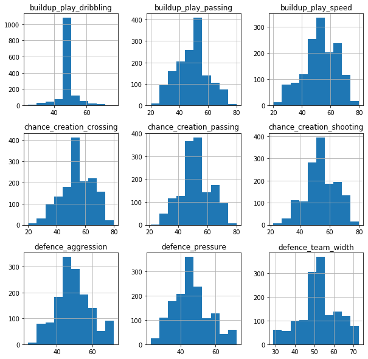

```python
# Use this, and more code cells, to explore your data. Don't forget to add
#   Markdown cells to document your observations and findings.
df_team_improved.hist(['buildup_play_speed', 'buildup_play_dribbling', 'buildup_play_passing', 'chance_creation_passing','chance_creation_crossing', 'chance_creation_shooting', 'defence_pressure', 'defence_aggression', 'defence_team_width'], figsize = (10, 10));
```

```python
df_team_improved.head()
```

|  | team_id | team_long_name | team_short_name | date | buildup_play_speed | buildup_play_dribbling | buildup_play_passing | chance_creation_passing | chance_creation_crossing | chance_creation_shooting | defence_pressure | defence_aggression | defence_team_width | year |
| --- | --- | --- | --- | --- | --- | --- | --- | --- | --- | --- | --- | --- | --- | --- |
| 0 | 9987 | KRC Genk | GEN | 2010-02-22 | 45 | 48.607362 | 45 | 50 | 35 | 60 | 70 | 65 | 70 | 2010 |
| 1 | 9987 | KRC Genk | GEN | 2011-02-22 | 66 | 48.607362 | 52 | 65 | 66 | 51 | 48 | 47 | 54 | 2011 |
| 2 | 9987 | KRC Genk | GEN | 2012-02-22 | 53 | 48.607362 | 55 | 55 | 48 | 56 | 47 | 45 | 55 | 2012 |
| 3 | 9987 | KRC Genk | GEN | 2013-09-20 | 58 | 48.607362 | 38 | 67 | 48 | 56 | 47 | 45 | 55 | 2013 |
| 4 | 9987 | KRC Genk | GEN | 2014-09-19 | 58 | 52.000000 | 38 | 67 | 48 | 56 | 47 | 45 | 55 | 2014 |

```python
col_team_improved = ['buildup_play_speed', 'buildup_play_dribbling', 'buildup_play_passing', 'chance_creation_passing','chance_creation_crossing', 'chance_creation_shooting', 'defence_pressure', 'defence_aggression', 'defence_team_width'];
df_team_improved_overtime = df_team_improved.groupby('year')[col_team_improved].mean();
```

```python
df_team_improved_overtime
```

| year | buildup_play_speed | buildup_play_dribbling | buildup_play_passing | chance_creation_passing | chance_creation_crossing | chance_creation_shooting | defence_pressure | defence_aggression | defence_team_width |
| --- | --- | --- | --- | --- | --- | --- | --- | --- | --- |
| 2010 | 49.647303 | 48.607362 | 46.182573 | 50.780083 | 53.253112 | 61.448133 | 49.697095 | 53.327801 | 52.365145 |
| 2011 | 54.004098 | 48.607362 | 48.045082 | 52.696721 | 54.713115 | 55.065574 | 46.221311 | 49.967213 | 53.241803 |
| 2012 | 50.661157 | 48.607362 | 49.330579 | 51.971074 | 53.847107 | 52.417355 | 44.599174 | 47.223140 | 51.975207 |
| 2013 | 52.202479 | 48.607362 | 48.615702 | 52.355372 | 54.392562 | 52.297521 | 45.148760 | 48.033058 | 52.314050 |
| 2014 | 54.086066 | 49.467213 | 49.200820 | 52.881148 | 53.409836 | 52.311475 | 44.807377 | 48.151639 | 51.745902 |
| 2015 | 54.131148 | 47.741803 | 49.540984 | 52.299180 | 52.790984 | 50.356557 | 45.659836 | 48.844262 | 51.483607 |

```python
df_team_improved_overtimenew = df_team_improved_overtime.mean(axis=1);
```

```python
df_team_improved_overtimenew = df_team_improved_overtimenew.to_frame('average_team_attr');
```

```python
df_team_improved_overtimenew
```

| year | average_team_attr |
| --- | --- |
| 2010 | 51.700956 |
| 2011 | 51.395809 |
| 2012 | 50.070239 |
| 2013 | 50.440763 |
| 2014 | 50.673497 |
| 2015 | 50.316485 |

```python
df_team_improved_overtimenew.reset_index(level=0, inplace=True);
df_team_improved_overtimenew
```

|  | year | average_team_attr |
| --- | --- | --- |
| 0 | 2010 | 51.700956 |
| 1 | 2011 | 51.395809 |
| 2 | 2012 | 50.070239 |
| 3 | 2013 | 50.440763 |
| 4 | 2014 | 50.673497 |
| 5 | 2015 | 50.316485 |

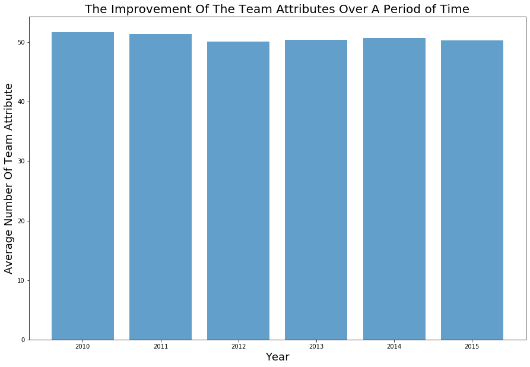

```python
plt.subplots(figsize=(15,10));
plt.bar(df_team_improved_overtimenew['year'], df_team_improved_overtimenew['average_team_attr'], alpha = (0.7));
plt.title('The Improvement Of The Team Attributes Over A Period of Time', fontsize = 20);
plt.xlabel('Year', fontsize = 18);
plt.ylabel('Average Number Of Team Attribute', fontsize = 18);
```

### Research Question 2 (Which players had the most penalties?!)

```
array([[<matplotlib.axes._subplots.AxesSubplot object at 0x000001B30C530448>]],
      dtype=object)
```

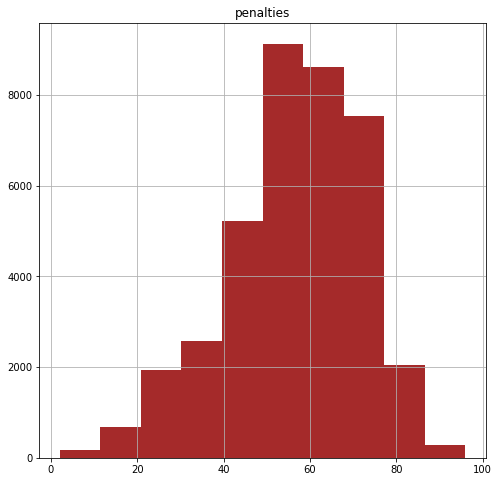

```python
# Use this, and more code cells, to explore your data. Don't forget to add
#   Markdown cells to document your observations and findings.
df_player_penalties.hist(figsize = (8,8),  color = 'brown');
```

```python
# Continue to explore the data to address your additional research
#   questions. Add more headers as needed if you have more questions to
#   investigate.
df_player_penalties.describe();
```

|  | penalties |
| --- | --- |
| count | 38172.000000 |
| mean | 56.358928 |
| std | 15.599055 |
| min | 2.000000 |
| 25% | 47.000000 |
| 50% | 58.000000 |
| 75% | 68.000000 |
| max | 96.000000 |

```python
df_player_penalties.head(2);
```

|  | player_name | penalties |
| --- | --- | --- |
| 0 | Aaron Appindangoye | 48.0 |
| 3 | Aaron Appindangoye | 47.0 |

```python
df_player_penaltiesnew = df_player_penalties.query('penalties >= 92');
```

```python
df_player_penaltiesnew.sort_values(by=['penalties'], ascending=False, inplace=True);
```

```python
df_player_penaltiesnew
```

|  | player_name | penalties |
| --- | --- | --- |
| 149591 | Rickie Lambert | 96.0 |
| 149595 | Rickie Lambert | 95.0 |
| 180726 | Xavi Hernandez | 95.0 |
| 113521 | Mario Balotelli | 95.0 |
| 12015 | Andrea Pirlo | 95.0 |
| 140506 | Paul Scholes | 95.0 |
| 2959 | Adrian Mutu | 94.0 |
| 53197 | Fabio Cannavaro | 94.0 |
| 138696 | Paolo Maldini | 94.0 |
| 40643 | David Trezeguet | 94.0 |
| 149600 | Rickie Lambert | 94.0 |
| 27353 | Cesc Fabregas | 94.0 |
| 154053 | Roy Makaay | 94.0 |
| 12013 | Andrea Pirlo | 94.0 |
| 72606 | Iker Casillas | 94.0 |
| 70296 | Hernan Crespo | 93.0 |
| 149606 | Rickie Lambert | 93.0 |
| 154052 | Roy Makaay | 93.0 |
| 140507 | Paul Scholes | 93.0 |
| 170032 | Thierry Henry | 93.0 |
| 113514 | Mario Balotelli | 93.0 |
| 180727 | Xavi Hernandez | 93.0 |
| 4916 | Alberto Gilardino | 93.0 |
| 183680 | Zlatan Ibrahimovic | 93.0 |
| 37972 | Dario Smoje | 93.0 |
| 7695 | Alexander Frei | 93.0 |
| 44631 | Dimitar Berbatov | 93.0 |
| 15409 | Antonio Cassano | 93.0 |
| 48203 | Eduardo | 93.0 |
| 55887 | Fernando Torres | 93.0 |
| 177447 | Vincent Kompany | 92.0 |
| 173622 | Tomas Rosicky | 92.0 |
| 170036 | Thierry Henry | 92.0 |
| 30893 | Clarence Seedorf | 92.0 |
| 15408 | Antonio Cassano | 92.0 |
| 155483 | Ryan Giggs | 92.0 |
| 25548 | Carlo Cudicini | 92.0 |
| 6530 | Alessandro Nesta | 92.0 |
| 151484 | Robin van Persie | 92.0 |
| 149859 | Rio Ferdinand | 92.0 |
| 27358 | Cesc Fabregas | 92.0 |
| 58185 | Francesco Totti | 92.0 |
| 30962 | Claude Makelele | 92.0 |
| 77273 | Jan Vennegoor of Hesselink | 92.0 |
| 40699 | David Villa | 92.0 |
| 48164 | Eduardo | 92.0 |
| 123658 | Michael Owen | 92.0 |
| 122755 | Michael Carrick | 92.0 |
| 114821 | Mark Schwarzer | 92.0 |
| 52795 | Fabian Monzon | 92.0 |
| 113498 | Mario Balotelli | 92.0 |
| 92757 | Kaka | 92.0 |
| 92153 | Juninho Pernambucano,20 | 92.0 |
| 77633 | Jaroslav Drobny | 92.0 |
| 88913 | Jose Moreira | 92.0 |

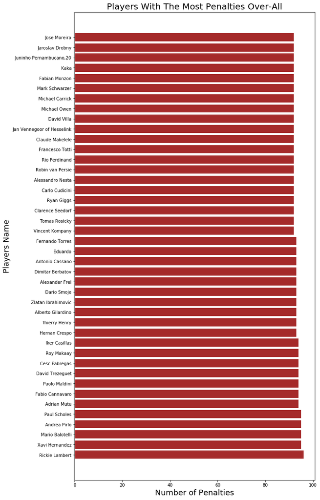

```python
plt.subplots(figsize = (10,20));
plt.barh(df_player_penaltiesnew['player_name'], df_player_penaltiesnew['penalties'], color = 'brown');
plt.title('Players With The Most Penalties Over-All', fontsize = 20);
plt.xlabel('Number of Penalties', fontsize = 18);
plt.ylabel('Players Name', fontsize = 18);
```

### Research Question 3 (How players Attribute helps the team imporved!)

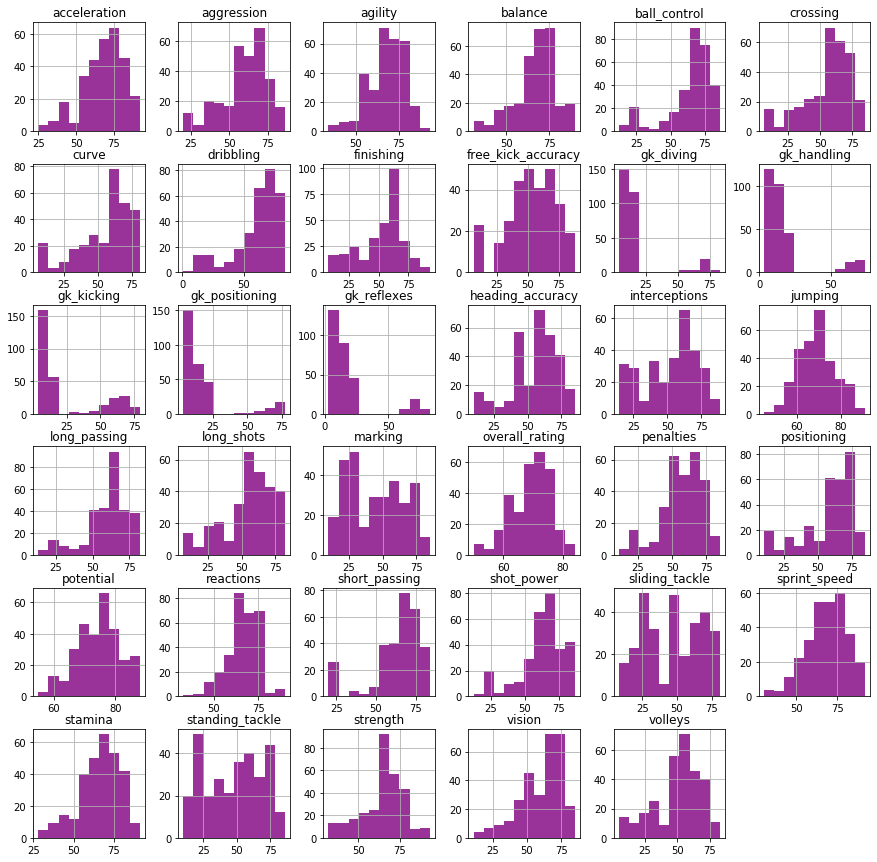

```python
# Continue to explore the data to address your additional research
#   questions. Add more headers as needed if you have more questions to
#   investigate.
df_player_improves.hist(figsize = (15,15), color = 'purple', alpha = 0.8);
```

```python
df_player_improves.describe();
```

|  | overall_rating | potential | crossing | finishing | heading_accuracy | short_passing | volleys | dribbling | curve | free_kick_accuracy | ... | vision | penalties | marking | standing_tackle | sliding_tackle | gk_diving | gk_handling | gk_kicking | gk_positioning | gk_reflexes |
| --- | --- | --- | --- | --- | --- | --- | --- | --- | --- | --- | --- | --- | --- | --- | --- | --- | --- | --- | --- | --- | --- |
| count | 299.000000 | 299.000000 | 299.000000 | 299.000000 | 299.000000 | 299.000000 | 299.000000 | 299.000000 | 299.000000 | 299.000000 | ... | 299.000000 | 299.000000 | 299.000000 | 299.000000 | 299.000000 | 299.000000 | 299.000000 | 299.000000 | 299.000000 | 299.000000 |
| mean | 69.127090 | 74.448161 | 56.608696 | 52.484950 | 55.197324 | 63.491639 | 50.744828 | 60.903010 | 54.417241 | 52.745819 | ... | 60.979310 | 56.996656 | 44.267559 | 48.408027 | 46.755172 | 16.742475 | 17.374582 | 23.956522 | 17.625418 | 17.732441 |
| std | 6.577155 | 7.035849 | 18.281837 | 18.891485 | 16.669443 | 15.621867 | 17.872133 | 18.284679 | 19.177073 | 19.592037 | ... | 15.279705 | 14.904055 | 20.686911 | 20.603009 | 20.656638 | 18.677515 | 17.005333 | 23.921603 | 17.845915 | 19.001112 |
| min | 50.000000 | 55.000000 | 6.000000 | 8.000000 | 10.000000 | 20.000000 | 5.000000 | 1.000000 | 6.000000 | 6.000000 | ... | 11.000000 | 11.000000 | 10.000000 | 10.000000 | 8.000000 | 4.000000 | 3.000000 | 4.000000 | 4.000000 | 3.000000 |
| 25% | 65.000000 | 69.000000 | 47.000000 | 43.500000 | 45.500000 | 58.000000 | 43.500000 | 55.000000 | 44.000000 | 40.000000 | ... | 52.000000 | 49.000000 | 25.000000 | 30.500000 | 28.000000 | 8.000000 | 8.000000 | 8.000000 | 8.000000 | 7.000000 |
| 50% | 70.000000 | 75.000000 | 61.000000 | 58.000000 | 57.000000 | 68.000000 | 55.000000 | 66.000000 | 60.000000 | 53.000000 | ... | 64.000000 | 58.000000 | 42.000000 | 50.000000 | 47.000000 | 11.000000 | 11.000000 | 11.000000 | 11.000000 | 12.000000 |
| 75% | 74.000000 | 79.000000 | 69.000000 | 65.000000 | 68.000000 | 74.000000 | 64.000000 | 73.500000 | 68.000000 | 68.000000 | ... | 74.000000 | 69.000000 | 62.000000 | 65.000000 | 66.000000 | 14.000000 | 20.000000 | 49.000000 | 20.000000 | 20.000000 |
| max | 84.000000 | 88.000000 | 85.000000 | 93.000000 | 85.000000 | 84.000000 | 83.000000 | 83.000000 | 81.000000 | 88.000000 | ... | 85.000000 | 85.000000 | 85.000000 | 86.000000 | 81.000000 | 83.000000 | 74.000000 | 79.000000 | 77.000000 | 83.000000 |

8 rows × 35 columns

```python
df_player_improves.head();
```

|  | team_long_name | overall_rating | potential | crossing | finishing | heading_accuracy | short_passing | volleys | dribbling | curve | ... | vision | penalties | marking | standing_tackle | sliding_tackle | gk_diving | gk_handling | gk_kicking | gk_positioning | gk_reflexes |
| --- | --- | --- | --- | --- | --- | --- | --- | --- | --- | --- | --- | --- | --- | --- | --- | --- | --- | --- | --- | --- | --- |
| 0 | KRC Genk | 67.0 | 71.0 | 49.0 | 44.0 | 71.0 | 61.0 | 44.0 | 51.0 | 45.0 | ... | 54.0 | 48.0 | 65.0 | 69.0 | 69.0 | 6.0 | 11.0 | 10.0 | 8.0 | 8.0 |
| 1 | Beerschot AC | 67.0 | 71.0 | 49.0 | 44.0 | 71.0 | 61.0 | 44.0 | 51.0 | 45.0 | ... | 54.0 | 48.0 | 65.0 | 69.0 | 69.0 | 6.0 | 11.0 | 10.0 | 8.0 | 8.0 |
| 2 | SV Zulte-Waregem | 62.0 | 66.0 | 49.0 | 44.0 | 71.0 | 61.0 | 44.0 | 51.0 | 45.0 | ... | 54.0 | 48.0 | 65.0 | 66.0 | 69.0 | 6.0 | 11.0 | 10.0 | 8.0 | 8.0 |
| 3 | Sporting Lokeren | 61.0 | 65.0 | 48.0 | 43.0 | 70.0 | 60.0 | 43.0 | 50.0 | 44.0 | ... | 53.0 | 47.0 | 62.0 | 63.0 | 66.0 | 5.0 | 10.0 | 9.0 | 7.0 | 7.0 |
| 4 | KSV Cercle Brugge | 61.0 | 65.0 | 48.0 | 43.0 | 70.0 | 60.0 | 43.0 | 50.0 | 44.0 | ... | 53.0 | 47.0 | 62.0 | 63.0 | 66.0 | 5.0 | 10.0 | 9.0 | 7.0 | 7.0 |

5 rows × 36 columns

```python
df_player_improvesnew = df_player_improves.groupby('team_long_name').sum();
```

```python
df_player_improvesnew = df_player_improvesnew.sum(axis=1);
```

```python
df_player_improvesnew
```

```
team_long_name
1. FC Kaiserslautern        1642.0
1. FC Köln                  1933.0
1. FC Nürnberg              1404.0
1. FSV Mainz 05             1451.0
AC Ajaccio                  2145.0
                             ...
Xerez Club Deportivo        1957.0
Zagłębie Lubin              1870.0
Zawisza Bydgoszcz           1790.0
Évian Thonon Gaillard FC    2164.0
Śląsk Wrocław               2212.0
Length: 296, dtype: float64
```

```python
df_player_improvesnew = df_player_improvesnew.to_frame('sum_of_player_attr');
df_player_improvesnew.head();
```

| team_long_name | sum_of_player_attr |
| --- | --- |
| 1. FC Kaiserslautern | 1642.0 |
| 1. FC Köln | 1933.0 |
| 1. FC Nürnberg | 1404.0 |
| 1. FSV Mainz 05 | 1451.0 |
| AC Ajaccio | 2145.0 |

```python
df_player_improvesnew.reset_index(level=0, inplace=True);
df_player_improvesnew.head();
```

|  | team_long_name | sum_of_player_attr |
| --- | --- | --- |
| 0 | 1. FC Kaiserslautern | 1642.0 |
| 1 | 1. FC Köln | 1933.0 |
| 2 | 1. FC Nürnberg | 1404.0 |
| 3 | 1. FSV Mainz 05 | 1451.0 |
| 4 | AC Ajaccio | 2145.0 |

```python
df_player_improvesnew.sort_values(by=['sum_of_player_attr'], ascending=False, inplace=True);
df_player_improvesnew.head(50);
```

|  | team_long_name | sum_of_player_attr |
| --- | --- | --- |
| 193 | Polonia Bytom | 4349.000000 |
| 221 | Royal Excel Mouscron | 4066.000000 |
| 286 | Widzew Łódź | 3675.000000 |
| 260 | Tondela | 2398.000000 |
| 270 | Uniao da Madeira | 2397.000000 |
| 196 | Queens Park Rangers | 2317.000000 |
| 8 | AJ Auxerre | 2299.000000 |
| 194 | Portimonense | 2285.000000 |
| 86 | FC Nantes | 2281.000000 |
| 203 | RCD Mallorca | 2269.000000 |
| 154 | Leicester City | 2266.000000 |
| 225 | SC Beira Mar | 2265.000000 |
| 278 | Villarreal CF | 2253.000000 |
| 39 | CA Osasuna | 2253.000000 |
| 55 | Crystal Palace | 2238.000000 |
| 42 | CD Tenerife | 2235.000000 |
| 199 | RC Deportivo de La Coruña | 2231.000000 |
| 114 | Girondins de Bordeaux | 2224.000000 |
| 273 | Valencia CF | 2223.000000 |
| 17 | Angers SCO | 2215.000000 |
| 152 | Lechia Gdańsk | 2213.000000 |
| 295 | Śląsk Wrocław | 2212.000000 |
| 69 | Estoril Praia | 2208.000000 |
| 151 | Lech Poznań | 2206.000000 |
| 233 | SM Caen | 2199.000000 |
| 178 | Odra Wodzisław | 2193.000000 |
| 182 | P. Warszawa | 2192.000000 |
| 110 | GKS Bełchatów | 2192.000000 |
| 222 | Ruch Chorzów | 2181.000000 |
| 18 | Arka Gdynia | 2180.000000 |
| 132 | Jagiellonia Białystok | 2180.000000 |
| 209 | Reading | 2179.000000 |
| 289 | Wisła Kraków | 2170.000000 |
| 37 | Brescia | 2164.000000 |
| 294 | Évian Thonon Gaillard FC | 2164.000000 |
| 148 | Le Havre AC | 2158.000000 |
| 128 | Hull City | 2155.724138 |
| 54 | Cracovia | 2152.000000 |
| 190 | Piast Gliwice | 2152.000000 |
| 205 | RSC Anderlecht | 2148.000000 |
| 243 | Southampton | 2148.000000 |
| 4 | AC Ajaccio | 2145.000000 |
| 134 | KAA Gent | 2138.000000 |
| 255 | Stoke City | 2135.724138 |
| 177 | OGC Nice | 2135.000000 |
| 59 | Dijon FCO | 2135.000000 |
| 108 | Fulham | 2129.724138 |
| 51 | Chelsea | 2129.724138 |
| 106 | Fortuna Düsseldorf | 2128.000000 |
| 53 | Club Brugge KV | 2120.000000 |

[figure not shown]

```python
df_player_improvesnew.plot(y='sum_of_player_attr', x='team_long_name', kind = 'barh', figsize = (20,100), color = 'purple');
plt.title('Players Atrributes In Relation To Teams ', fontsize = 30);
plt.xlabel('Sum Of All Atrributes', fontsize = 20);
plt.ylabel('Team Names', fontsize = 20);
```

## Conclusions

> **Tip**: Finally, summarize your findings and the results that have been performed. Make sure that you are clear with regards to the limitations of your exploration. If you haven't done any statistical tests, do not imply any statistical conclusions. And make sure you avoid implying causation from correlation!

> **Tip**: Once you are satisfied with your work here, check over your report to make sure that it is satisfies all the areas of the rubric (found on the project submission page at the end of the lesson). You should also probably remove all of the "Tips" like this one so that the presentation is as polished as possible.

## Submitting your Project

> Before you submit your project, you need to create a .html or .pdf version of this notebook in the workspace here. To do that, run the code cell below. If it worked correctly, you should get a return code of 0, and you should see the generated .html file in the workspace directory (click on the orange Jupyter icon in the upper left).

> Alternatively, you can download this report as .html via the **File** > **Download as** submenu, and then manually upload it into the workspace directory by clicking on the orange Jupyter icon in the upper left, then using the Upload button.

> Once you've done this, you can submit your project by clicking on the "Submit Project" button in the lower right here. This will create and submit a zip file with this .ipynb doc and the .html or .pdf version you created. Congratulations!

```python
from subprocess import call
call(['python', '-m', 'nbconvert', 'Investigate_a_Dataset.ipynb'])
```